# General EDA plots and models

[Homepage](https://mcmarius.github.io/InformationVisualization/)

```r
library(RSQLite)
library(tidyverse)
library(hrbrthemes)
library(kableExtra)
library(RColorBrewer)
library(viridis)
library(d3heatmap)
library(naivebayes)
library(yardstick)
library(ranger)
library(caret)
library(treemap)
# library(d3treeR)
library(highcharter)
#library(Metrics)
# library(ggridges)
```

```r
con <- dbConnect(RSQLite::SQLite(), "../wildfire/FPA_FOD_20170508.sqlite")
causes <- dbGetQuery(con, "SELECT COUNT(*) AS nr, STAT_CAUSE_DESCR AS cause_name FROM Fires GROUP BY STAT_CAUSE_DESCR")

#knitr::opts_chunk$set(fig.width=16)

# https://www.reddit.com/r/RStudio/comments/euew3l/preview_button_gone_can_only_knit/

# some color ideas from https://colorbrewer2.org
```

# Main causes

## What are the causes for wildfires?

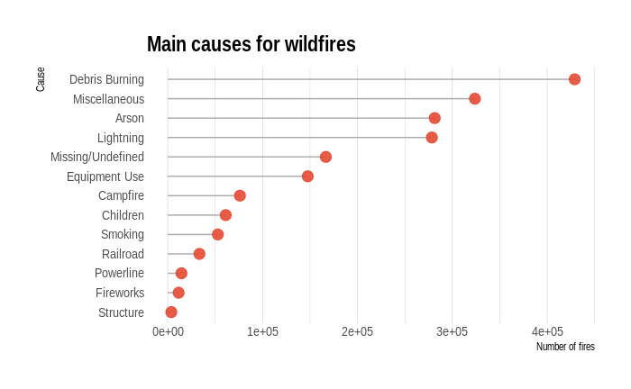

```r
# https://www.data-to-viz.com/graph/lollipop.html

causes %>%
  arrange(nr) %>%
  mutate(cause_name=factor(cause_name, cause_name)) %>%
  ggplot( aes(x=cause_name, y=nr) ) +
    geom_segment(aes(x=cause_name, xend=cause_name, y=0, yend=nr), color="darkgrey") +
    geom_point(size=4, color='#e34a33', alpha=0.9) +
    coord_flip() +
    theme_ipsum() +
    # xlab("") +
    labs(x="Cause",y="Number of fires", title = 'Main causes for wildfires') +
    #labs(x="",y="", title = 'Main causes for wildfires') +
    theme(
      panel.grid.minor.y = element_blank(),
      panel.grid.major.y = element_blank(),
      #legend.position="none",
      #axis.text = element_text(hjust = 0.5)
    )
```

```r
fire_size_class <- dbGetQuery(con, "SELECT COUNT(*) AS nr, FIRE_SIZE_CLASS AS fire_size FROM Fires GROUP BY FIRE_SIZE_CLASS")
```

## Almost 2 million fires? Is there anything left?

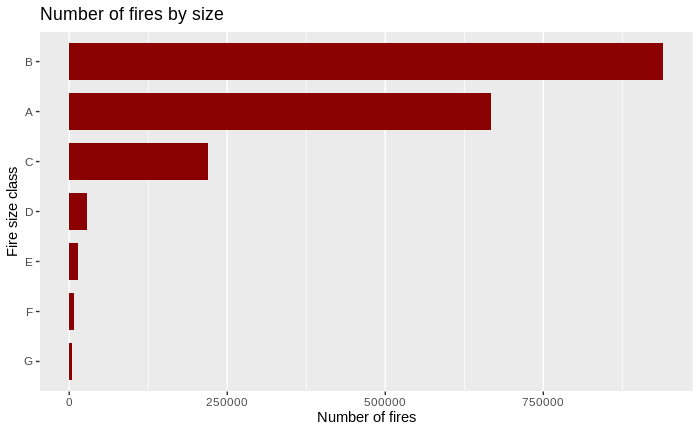

```r
# https://www.data-to-viz.com/graph/barplot.html

fire_size_class %>%
  arrange(nr) %>%
  mutate(fire_size=factor(fire_size, fire_size)) %>%
  ggplot( aes(x=fire_size, y=nr) ) +
    #geom_segment(aes(x=cause_name, xend=fire_size, y=0, yend=nr), color="darkgrey") +
    #geom_point(size=4, color='#e34a33', alpha=0.9) +
    geom_bar(stat='identity', fill='darkred', width = 0.75) +
    coord_flip() +
    #theme_ipsum() +
    #xlab("") +
    #labs(x="",y="", title = 'Number of fires by size') +
    labs(x="Fire size class",y="Number of fires", title = 'Number of fires by size') +
    theme(
      panel.grid.minor.x = element_line(),
      panel.grid.minor.y = element_blank(),
      panel.grid.major.y = element_blank(),
      #axis.ticks.x = fire_size_class$nr
      #legend.position="none",
      #axis.text = element_text(hjust = 0.5)
    ) # + scale_y_discrete(fire_size_class$nr)
```

## What are the most frequent causes for the biggest fires?

Note that these are normalized by column (fire class).

```r
# https://www.data-to-viz.com/graph/heatmap.html
# https://www.r-graph-gallery.com/215-the-heatmap-function.html

fire_cause <- dbGetQuery(con,
                         "SELECT STAT_CAUSE_DESCR AS cause, FIRE_SIZE_CLASS AS fire_class, COUNT(FIRE_SIZE_CLASS) AS nr
                         FROM Fires
                         WHERE FIRE_SIZE_CLASS IN ('D', 'E', 'F', 'G')
                         GROUP BY 1, 2")
```

```r
nrows <- length(levels(factor(fire_cause$cause)))
ncols <- length(levels(factor(fire_cause$fire_class)))
matr3 <- t(matrix(fire_cause$nr, nrow = ncols, ncol = nrows))
rownames(matr3) <- levels(factor(fire_cause$cause))
colnames(matr3) <- levels(factor(fire_cause$fire_class))
coul <- colorRampPalette(brewer.pal(8, "OrRd"))(25)
d3heatmap(matr3, scale = 'column', Colv = NA, Rowv = NA, col=coul,  yaxis_width = 200, width = 700, title = 'The most frequent causes for the biggest fires')
```

[interactive chart not shown]

```r
# sources: same as previous heatmap

sfire_cause <- dbGetQuery(con,
                         "SELECT STAT_CAUSE_DESCR AS cause, FIRE_SIZE_CLASS AS fire_class, COUNT(FIRE_SIZE_CLASS) AS nr
                         FROM Fires
                         WHERE FIRE_SIZE_CLASS IN ('A', 'B', 'C')
                         GROUP BY 1, 2")
```

```r
snrows <- length(levels(factor(sfire_cause$cause)))
sncols <- length(levels(factor(sfire_cause$fire_class)))
smatr3 <- t(matrix(sfire_cause$nr, nrow = sncols, ncol = snrows))
rownames(smatr3) <- levels(factor(sfire_cause$cause))
colnames(smatr3) <- levels(factor(sfire_cause$fire_class))
scoul <- colorRampPalette(brewer.pal(8, "OrRd"))(25)
d3heatmap(smatr3, scale = 'column', Colv = NA, Rowv = NA, col=scoul, yaxis_width = 200, width = 700, main = 'The most frequent causes for small fires')
```

[interactive chart not shown]

# Time series

## Are there fires all year long?

```r
# source: http://www.cookbook-r.com/Graphs/Multiple_graphs_on_one_page_(ggplot2)/
multiplot <- function(..., plotlist=NULL, file, cols=1, layout=NULL) {
  library(grid)

  # Make a list from the ... arguments and plotlist
  plots <- c(list(...), plotlist)

  numPlots = length(plots)

  # If layout is NULL, then use 'cols' to determine layout
  if (is.null(layout)) {
    # Make the panel
    # ncol: Number of columns of plots
    # nrow: Number of rows needed, calculated from # of cols
    layout <- matrix(seq(1, cols * ceiling(numPlots/cols)),
                    ncol = cols, nrow = ceiling(numPlots/cols))
  }

 if (numPlots==1) {
    print(plots[[1]])

  } else {
    # Set up the page
    grid.newpage()
    pushViewport(viewport(layout = grid.layout(nrow(layout), ncol(layout))))

    # Make each plot, in the correct location
    for (i in 1:numPlots) {
      # Get the i,j matrix positions of the regions that contain this subplot
      matchidx <- as.data.frame(which(layout == i, arr.ind = TRUE))

      print(plots[[i]], vp = viewport(layout.pos.row = matchidx$row,
                                      layout.pos.col = matchidx$col))
    }
  }
}

# end of multiplot
# source: http://www.cookbook-r.com/Graphs/Multiple_graphs_on_one_page_(ggplot2)/
##############################################################################
```

```r
units_by_type <- dbGetQuery(con, "SELECT count(distinct(units.UnitId)) AS nr_units, count(distinct(f.fod_id)) AS nr_fires, units.UnitType FROM Fires f INNER JOIN NWCG_UnitIDActive_20170109 units ON f.NWCG_REPORTING_UNIT_ID = units.UnitId GROUP BY units.UnitType")

# units_by_type
# nr_units | nr_fires | UnitType
#     7            40       Interagency
#    11        3725     Tribe
#   526       86871     US County/Local
#   902      477787       US Federal
#   177     1277285     US State
```

# Another possible explanation besides global warming

## How many wildfires are managed by each unit type?

The following pattern might uncover organizational issues.

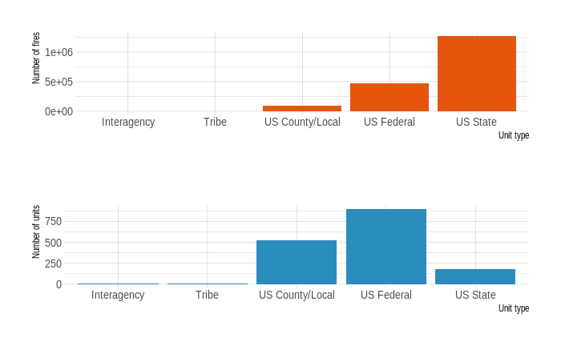

```r
# https://www.r-graph-gallery.com/37-barplot-with-number-of-observation.html
data <- data.frame(
  counts = units_by_type[,1:2],#) %>% map_int(1L)),
  units = rep(units_by_type[,3], times=1)
)

# same as the barplot above
# colors picked to show fires with some sort of red and units with some sort of blue (obvious reasons)

p1 <- data  %>%
  #mutate(year=as.factor(year)) %>%
  ggplot( aes(x=units, y=counts.nr_fires)) +
    geom_bar(stat="identity", fill='#e6550d') +
    scale_fill_viridis(discrete=TRUE, name="") +
    theme_ipsum() +
    xlab("Unit type")+
    ylab("Number of fires")

p2 <- data  %>%
  #mutate(year=as.factor(year)) %>%
  ggplot( aes(x=units, y=counts.nr_units)) +
    geom_bar(stat="identity", fill='#2b8cbe') +
    scale_fill_viridis(discrete=TRUE, name="") +
    theme_ipsum() +
    xlab("Unit type")+
    ylab("Number of units")
multiplot(p1, p2)
```

Further down the line, we notice many agencies each with very few units.

```r
# 398 units with NULL agency
data <- data.frame(
  id = agencies$Agency,
  name = agencies$agency_name,
  value = agencies$nr,
)
```

[output not shown]

## There are many agencies with very few units each

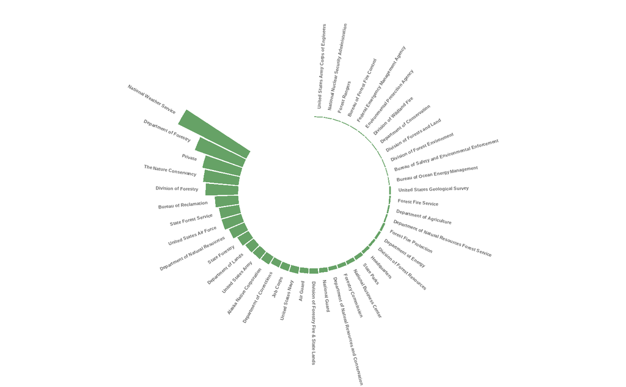

```r
# https://www.r-graph-gallery.com/296-add-labels-to-circular-barplot

# Get the name and the y position of each label
data <- data  %>% filter(name != "<NA>") %>% arrange(value) %>%
   mutate(id=factor(id, id))
label_data <- data %>% filter(name != "<NA>")
number_of_bar <- nrow(label_data)
angle <- 90 - 360 * (as.integer(label_data$id)-0.5) /number_of_bar     # I substract 0.5 because the letter must have the angle of the center of the bars. Not extreme right(1) or extreme left (0)
label_data$hjust <- ifelse( angle < -90, 1, 0)
label_data$angle <- ifelse(angle < -90, angle+180, angle)

# Make the plot
p <- data %>% filter(name != "<NA>") %>%
  arrange(value) %>%
  mutate(id=factor(id, id)) %>%
  ggplot(aes(x=as.factor(id), y=value)) +       # Note that id is a factor. If x is numeric, there is some space between the first bar
  geom_bar(stat="identity", fill=alpha("darkgreen", 0.6)) +
  ylim(-100,120) +
  theme_minimal() +
  theme(
    axis.text = element_blank(),
    axis.title = element_blank(),
    panel.grid = element_blank(),
    plot.margin = unit(rep(-1,4), "cm")
  ) +
  coord_polar(start = 0) +
  #labs(title = 'Number of units per agency') +
  geom_text(data=label_data, aes(x=id, y=value+10, label=name, hjust=hjust), color="black", fontface="bold",alpha=0.6, size=3, angle= label_data$angle, inherit.aes = FALSE )


p
```

```r
#ggplot2::ggsave('circular_plot.pdf', p, device = 'pdf')
```

So indeed it might also be an administrative problem, as the previous plots suggest. Despite having many agencies, these agencies do not have enough units.

[output not shown]

```r
state_agencies <- dbGetQuery(
  con, "
    SELECT
      COUNT(*) AS nr,
      agency
    FROM NWCG_UnitIDActive_20170109
    WHERE unitType = 'US State'
    GROUP BY agency
    ORDER BY 1 DESC")
state_agencies
```

| nr | Agency |
| --- | --- |
| 240 | OES |
| 168 | NA |
| 67 | DOF |
| 42 | DVF |
| 27 | SFS |
| 24 | CDF |
| 22 | DNR |
| 17 | SF |
| 14 | DL |
| 9 | DC |

[output cut: 20 more lines]

## Noisy data

```r
parsed_datetime <- function(col_prefix) {
  glue::glue("datetime(date({col_prefix}_date) || ' ' || substr({col_prefix}_time, 1, 2) || ':' || substr({col_prefix}_time, 3, 4) || ':00')")
}

parsed_time <- function(col_prefix) {
  glue::glue("substr({col_prefix}_time, 1, 2) || ':' || substr({col_prefix}_time, 3, 4) || ':00'")
}
```

```r
# containment time - discovery time
all_diffs <- dbGetQuery(con, glue::glue(
  "WITH res AS (
     SELECT
       fire_name,
       fire_size,
       discovery_date,
       cont_date,
       {parsed_datetime('f.discovery')} AS discovery,
       {parsed_datetime('f.cont')} AS contained,
       cont_date - discovery_date AS days_diff,
       time(strftime('%s', {parsed_time('cont')}) - strftime('%s', {parsed_time('discovery')}), 'unixepoch') AS h_diff,
       fire_year,
       fire_size_class
     FROM fires f
     WHERE
           cont_date IS NOT NULL
       AND cont_time IS NOT NULL
       AND discovery_date IS NOT NULL
       AND discovery_time IS NOT NULL -- AND days_diff > 0
     ORDER BY days_diff DESC, h_diff DESC
     --LIMIT -1 OFFSET 1000
     --LIMIT 40
  )

  SELECT days_diff, h_diff, cast(strftime('%s', contained) - strftime('%s', discovery) as real) / (24*3600) AS tm_diff, fire_size_class FROM res", .con=con))
  # SELECT avg(days_diff), fire_size_class FROM res GROUP BY 2", .con=con))
  #SELECT fire_year, fire_size, discovery, contained, days_diff, h_diff FROM res", .con=con))
  #SELECT count(*) from res", .con=con))
#strftime('%s', {parsed_datetime('f.cont')}) - strftime('%s', {parsed_datetime('f.discovery')}) AS duration
#end
all_diffs[1:7,]
```

|  | days_diff | h_diff | tm_diff | fire_size_class |
| --- | --- | --- | --- | --- |
| 1 | 3653 | 01:30:00 | 3653.062 | B |
| 2 | 3653 | 01:00:00 | 3653.042 | B |
| 3 | 3653 | 00:15:00 | 3653.010 | A |
| 4 | 3653 | 00:15:00 | 3653.010 | B |
| 5 | 3287 | 00:00:00 | 3287.000 | B |
| 6 | 3287 | 00:00:00 | 3287.000 | A |
| 7 | 1881 | 02:00:00 | 1881.083 | D |

There seem to be bogus entries: small fires not being estinguished for more than a couple of years

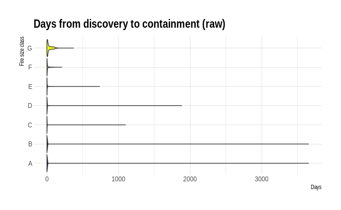

```r
# links: see below

ggplot(all_diffs, aes(x = `days_diff`, y = `fire_size_class`, fill = ..y..)) +
  geom_violin(scale = 3) +
  scale_fill_viridis(name = "days_diff", option = "C") +
  labs(title = 'Days from discovery to containment (raw)', x = "Days", y = "Fire size class") +
  theme_ipsum() +
    theme(
      legend.position="none",
      #panel.spacing = unit(0.1, "lines"),
      strip.text.x = element_text(size = 8)
    )
```

We remove the first thousand entries and fires lasting more than 2 days

```r
# https://www.data-to-viz.com/graph/violin.html
# https://www.data-to-viz.com/caveat/boxplot.html
all_diffs[-8000:0,][1,]
```

|  | days_diff | h_diff | tm_diff | fire_size_class |
| --- | --- | --- | --- | --- |
| 8001 | 30 | 19:30:00 | 29.8125 | A |

```r
all_diffs2 = all_diffs[-1000:0,] %>% filter(fire_size_class < 'E') %>% filter(tm_diff < 2) # || fire_size_class == 'C')
all_diffs2
```

| days_diff | h_diff | tm_diff | fire_size_class |
| --- | --- | --- | --- |
| 2 | 23:59:00 | 1.999306 | A |
| 2 | 23:59:00 | 1.999306 | B |
| 2 | 23:59:00 | 1.999306 | A |
| 2 | 23:59:00 | 1.999306 | A |
| 2 | 23:59:00 | 1.999306 | A |
| 2 | 23:59:00 | 1.999306 | A |
| 2 | 23:59:00 | 1.999306 | B |
| 2 | 23:59:00 | 1.999306 | B |
| 2 | 23:59:00 | 1.999306 | A |
| 2 | 23:59:00 | 1.999306 | A |

[output cut: 990 more lines]

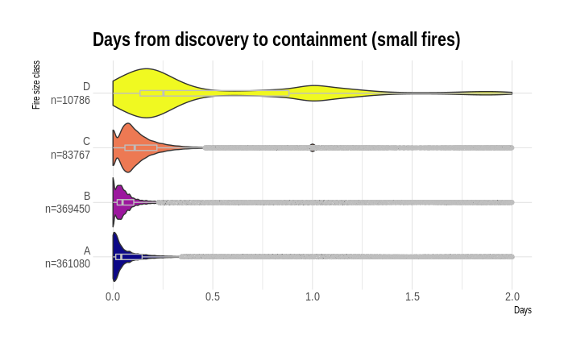

```r
sample_size = all_diffs2 %>% group_by(fire_size_class) %>% summarize(num=n())
all_diffs2 %>%
  left_join(sample_size) %>%
  mutate(fire_size = paste0(fire_size_class, "\n", "n=", num)) %>%
ggplot(aes(x = tm_diff, y = fire_size, fill=..y..)) +
  geom_violin(scale = 3) +
    geom_boxplot(width=0.1, color="grey", alpha=0.2) +
  scale_fill_viridis(name = "days_diff", option = "C") +
  labs(title = 'Days from discovery to containment (small fires)', x = "Days", y = "Fire size class") +
  theme_ipsum() +
    theme(
      legend.position="none",
      #panel.spacing = unit(0.1, "lines"),
      strip.text.x = element_text(size = 8)
    )
```

We remove fires lasting more than a year

```r
all_diffs3 = all_diffs %>% filter(fire_size_class > 'D') %>% filter(tm_diff < 365) # || fire_size_class == 'C')
all_diffs3
```

| days_diff | h_diff | tm_diff | fire_size_class |
| --- | --- | --- | --- |
| 329 | 00:00:00 | 329.00000 | E |
| 312 | 03:00:00 | 312.12500 | G |
| 277 | 20:00:00 | 276.83333 | E |
| 243 | 02:00:00 | 243.08333 | E |
| 237 | 23:00:00 | 236.95833 | G |
| 207 | 03:00:00 | 207.12500 | F |
| 204 | 04:44:00 | 204.19722 | G |
| 193 | 22:15:00 | 192.92708 | E |
| 191 | 18:30:00 | 190.77083 | F |
| 184 | 22:30:00 | 183.93750 | G |

[output cut: 990 more lines]

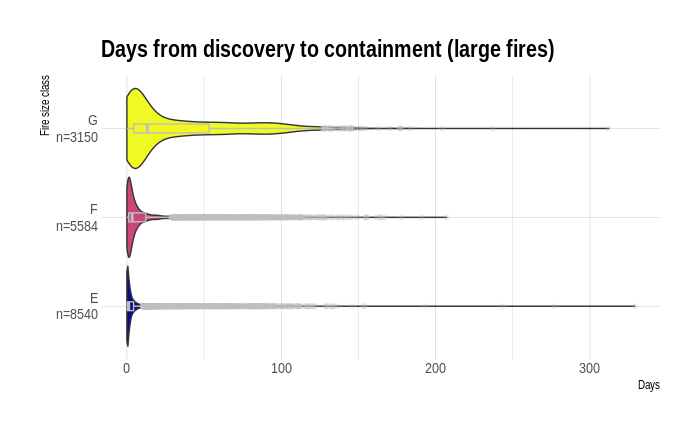

```r
sample_size = all_diffs3 %>% group_by(fire_size_class) %>% summarize(num=n())
all_diffs3 %>%
  left_join(sample_size) %>%
  mutate(fire_size = paste0(fire_size_class, "\n", "n=", num)) %>%
ggplot(aes(x = tm_diff, y = fire_size, fill=..y..)) +
  geom_violin(scale = 3) +
    geom_boxplot(width=0.1, color="grey", alpha=0.2) +
  scale_fill_viridis(name = "days_diff", option = "C") +
  labs(title = 'Days from discovery to containment (large fires)', x = "Days", y = "Fire size class") +
  theme_ipsum() +
    theme(
      legend.position="none",
      #panel.spacing = unit(0.1, "lines"),
      strip.text.x = element_text(size = 8)
    )
```

# Geographic data

## What regions burned the most?

```r
# units.GeographicArea is the same as units.gacc, except that California is split into Northern California and Southern California
# as treemap
total_burnt <- dbGetQuery(
  con,
  "SELECT
     SUM(f.fire_size) AS total,
     CASE units.GeographicArea
        WHEN 'NA' THEN 'National'
        WHEN 'IN' THEN 'International'
        WHEN 'AK' THEN 'Alaska'
        WHEN 'CA' THEN 'California'
        WHEN 'EA' THEN 'Eastern Area'
        WHEN 'GB' THEN 'Great Basin'
        WHEN 'NR' THEN 'Northern Rockies'
        WHEN 'NW' THEN 'Northwest'
        WHEN 'RM' THEN 'Rocky Mountain'
        WHEN 'SA' THEN 'Southern Area'
        WHEN 'SW' THEN 'Southwest'
     END geographic_area
   FROM Fires f INNER JOIN NWCG_UnitIDActive_20170109 units ON f.NWCG_REPORTING_UNIT_ID = units.UnitId GROUP BY units.GeographicArea ORDER BY 1 DESC")

total_burnt
```

| total | geographic_area |
| --- | --- |
| 32233094 | Alaska |
| 25916286 | Great Basin |
| 24047682 | Southern Area |
| 13040136 | Northwest |
| 12887959 | Southwest |
| 12806736 | California |
| 8487613 | Northern Rockies |
| 6673726 | Rocky Mountain |
| 3000527 | Eastern Area |

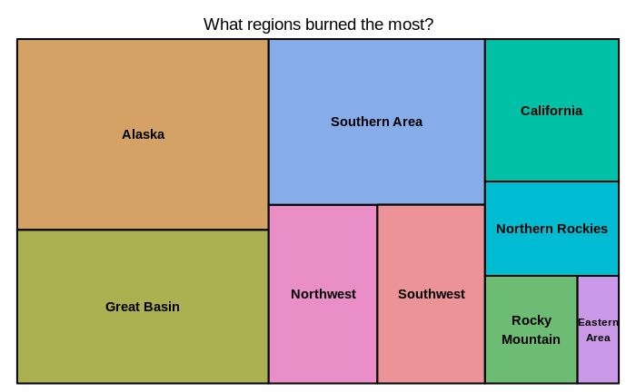

```r
# https://www.r-graph-gallery.com/234-a-very-basic-treemap.html

treemap::treemap(total_burnt, index = 'geographic_area', vSize = 'total', type = 'index', title = "What regions burned the most?")
```

```r
# https://github.com/jakevdp/data-USstates
abbrevs <- read.csv('us_state-abbrevs.csv')
census <- read.csv('us_state-population.csv') %>%
  filter(ages == "total" & year == 2012) %>%
  merge(abbrevs, by.x = c("state.region"), by.y = c("abbreviation")) %>%
  select(state, population)

# note: Alaska and California regions have been renamed because the highcharts
# library requires unique labels across all levels
total_burnt2 <- dbGetQuery(
  con,
  "SELECT
     SUM(f.fire_size) AS total, f.state AS abbreviation,
     CASE units.GeographicArea
        WHEN 'NA' THEN 'National'
        WHEN 'IN' THEN 'International'
        WHEN 'AK' THEN 'Alaska (region)'
        WHEN 'CA' THEN 'California (region)'
        WHEN 'EA' THEN 'Eastern Area'
        WHEN 'GB' THEN 'Great Basin'
        WHEN 'NR' THEN 'Northern Rockies'
        WHEN 'NW' THEN 'Northwest'
        WHEN 'RM' THEN 'Rocky Mountain'
        WHEN 'SA' THEN 'Southern Area'
        WHEN 'SW' THEN 'Southwest'
     END geographic_area
   FROM Fires f INNER JOIN NWCG_UnitIDActive_20170109 units ON f.NWCG_REPORTING_UNIT_ID = units.UnitId
   GROUP BY units.GeographicArea, f.state
   ORDER BY 1 DESC") %>%
# total_burnt2 <-
  # dbGetQuery(con, "SELECT SUM(f.fire_size) AS total, state,  FROM Fires f GROUP BY state ORDER BY 1 DESC") %>%
  merge(abbrevs) %>% #, by.x = c("state"), by.y = c("abbreviation")) %>%
  merge(census)
total_burnt2$affected <- (total_burnt2$population * total_burnt2$total)
```

**Important notice!** A state can be in one or more regions. This is how regions are defined in the Fires dataset. This is an issue for our treemaps, because we have no means of “splitting” a state population by region. This issue is only strikingly visible with California, so we manually force it to be just in California region.

We still have duplicate entries, but they should not affect the overall visualization.

```r
# https://www.datanovia.com/en/lessons/highchart-interactive-treemap-in-r/
# https://www.rdocumentation.org/packages/highcharter/versions/0.8.2/topics/hctreemap
# https://api.highcharts.com/highcharts/plotOptions.treemap.allowTraversingTree
# options(highcharter.theme = hc_theme_smpl(tooltip = list(valueDecimals = 2)))

total_burnt2
# tree <- treemap(
#   total_burnt2,
#   index = c('geographic_area', 'state'),
#   vSize = 'affected',
#   type = 'index',
#   title = "What states were the most affected?",
#   align.labels = list(c('center', 'center'), c('center', 'center')))
total_burnt22 <- total_burnt2 %>% filter((geographic_area != "California (region)" & state != "California") | geographic_area == "California (region)")
```

```r
hchart(
  data_to_hierarchical(total_burnt22, group_vars = c(geographic_area, state), size_var = 'population'),
  type = "treemap",
  allowTraversingTree = T,
  layoutAlgorithm = "sliceAndDice",  # squarified
  layoutStartingDirection = "vertical"  # horizontal
) %>% hc_title(text = 'US regions by population')
```

[interactive chart not shown]

## The most affected regions

```r
hchart(
  data_to_hierarchical(total_burnt2, group_vars = c(geographic_area, state), size_var = 'affected'),
  type = "treemap", allowTraversingTree = T,
  layoutAlgorithm = "sliceAndDice",  # squarified
  layoutStartingDirection = "vertical"  # horizontal
) %>%
  hc_title(text = 'US regions by burned area and population')
```

[interactive chart not shown]

```r
  #hc_tooltip(enabled = F)
# d3tree(tree, 'What regions and states were the most affected?', width = '780', height = '450')
```

## Deeper dive into geographic EDA

# Are fires predictable?

Unfortunately, data for large fires is incomplete or missing.

Therefore, the following prediction tasks are limited to small fires.

## Naive Bayes to predict the size of a fire

```r
# https://yardstick.tidymodels.org/reference/conf_mat.html
all_data <- dbGetQuery(con, "SELECT DISTINCT (fod_id), * from fires f INNER JOIN NWCG_UnitIDActive_20170109 units ON f.NWCG_REPORTING_UNIT_ID = units.UnitId")
x <- all_data %>% select(STAT_CAUSE_DESCR, DISCOVERY_DOY,UnitType,Department,GeographicArea, OWNER_DESCR, STATE, FIRE_SIZE_CLASS) %>% drop_na() %>% filter(FIRE_SIZE_CLASS < "D")

all_data[1,]
```

|  | FOD_ID | OBJECTID | FOD_ID | FPA_ID | SOURCE_SYSTEM_TYPE | SOURCE_SYSTEM | NWCG_REPORTING_AGENCY | NWCG_REPORTING_UNIT_ID | NWCG_REPORTING_UNIT_NAME | SOURCE_REPORTING_UNIT | SOURCE_REPORTING_UNIT_NAME | LOCAL_FIRE_REPORT_ID | LOCAL_INCIDENT_ID | FIRE_CODE | FIRE_NAME | ICS_209_INCIDENT_NUMBER | ICS_209_NAME | MTBS_ID | MTBS_FIRE_NAME | COMPLEX_NAME | FIRE_YEAR | DISCOVERY_DATE | DISCOVERY_DOY | DISCOVERY_TIME | STAT_CAUSE_CODE | STAT_CAUSE_DESCR | CONT_DATE | CONT_DOY | CONT_TIME | … |
| --- | --- | --- | --- | --- | --- | --- | --- | --- | --- | --- | --- | --- | --- | --- | --- | --- | --- | --- | --- | --- | --- | --- | --- | --- | --- | --- | --- | --- | --- | --- |
| 1 | 1 | 1 | 1 | FS-1418826 | FED | FS-FIRESTAT | FS | USCAPNF | Plumas National Forest | 0511 | Plumas National Forest | 1 | PNF-47 | BJ8K | FOUNTAIN | NA | NA | NA | NA | NA | 2005 | 2453404 | 33 | 1300 | 9 | Miscellaneous | 2453404 | 33 | 1730 | … |

```r
# nb <- naive_bayes(x = x[1:n,], y = y[1:n], laplace = 1e-5)
df <- sample(as.data.frame(x))

data_split <- df$FIRE_SIZE_CLASS %>% createDataPartition(p = 0.8, list = FALSE)
train  <- df[data_split, ]
test <- df[-data_split, ]

test2 <- test
test <- test %>% select(!matches("FIRE_SIZE_CLASS"))

nb <- naive_bayes(FIRE_SIZE_CLASS ~ ., train, laplace = 1e-7)
preds <- predict(nb, test, type = "class")
# accuracy
sum(test2$FIRE_SIZE_CLASS == preds)/length(test2$FIRE_SIZE_CLASS)
```

```
[1] 0.5943173
```

```r
# 0.5924989
test2$pred <- preds
#as.tibble(df[n+1:n1,]$FIRE_SIZE_CLASS) %>% conf_mat(preds, fire_size_class)
```

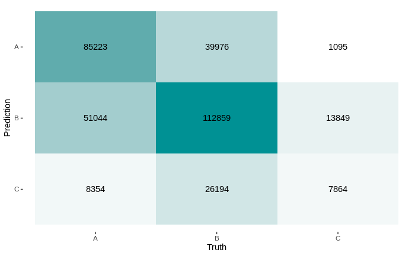

```r
autoplot(cm, type="heatmap")+scale_fill_gradient(low="white", high="#009194")
```

## Random forest to predict the cause of a fire

```r
# https://stackoverflow.com/a/64539733
# https://www.datanovia.com/en/blog/ggplot-axis-ticks-set-and-rotate-text-labels/
# https://bradleyboehmke.github.io/HOML/random-forest.html

x <- all_data %>% select(STAT_CAUSE_DESCR, DISCOVERY_DOY,UnitType,Department,GeographicArea, OWNER_DESCR, STATE, FIRE_SIZE, FIRE_SIZE_CLASS, CONT_DOY, SOURCE_SYSTEM_TYPE, NWCG_REPORTING_UNIT_NAME, LATITUDE, LONGITUDE, SOURCE_REPORTING_UNIT_NAME) %>% drop_na() %>% filter(FIRE_SIZE_CLASS < "D") %>% select(!matches("FIRE_SIZE_CLASS"))
x$STAT_CAUSE_DESCR <- as.factor(x$STAT_CAUSE_DESCR)

df <- sample(as.data.frame(x))
data_split <- df$STAT_CAUSE_DESCR %>% createDataPartition(p = 0.8, list = FALSE)
train  <- df[data_split, ]
test <- df[-data_split, ]

test2 <- test
test <- test %>% select(!matches("STAT_CAUSE_DESCR"))

model3 <- ranger(STAT_CAUSE_DESCR ~ ., train, num.trees = 20)

model3$confusion.matrix
```

```
                   predicted
true                 Arson Campfire Children Debris Burning Equipment Use Fireworks Lightning Miscellaneous Missing/Undefined Powerline Railroad Smoking Structure   <NA>
  Arson              56953     1344     1804          27560          2095       392      4228         14665              1112        69       68     174        14      7
  Campfire            1961    14759      297           6690          1068       144     13292          4930               352        54       47     284        12      4
  Children            2672      455     4086           8610           867       395      1518          3730               374        29       32     110        21      2
  Debris Burning     19497     1682     1950          97413          2376       480      4474         11649              2474       117      127     250        42     19
  Equipment Use       3616     1160      588          11547          8052       284      5431          8728              1232       125       76     193        33      2
  Fireworks            733      135      240           1023           277      3958       809           758               107         7       13      31         6      2
  Lightning           2057     4012      326           6127          1858       341    147393          8062               951        96       78     229        15     19
  Miscellaneous       8802     4275     1804          19299          4446       752     12064         67835              2612       159      165     418        23     12
  Missing/Undefined    423      167       46           1451           422        40      1602          1696             46798        18       39      52         7      6
  Powerline            523       94       99           2007           522        47       951          1587               123       152       13      21         3      1
  Railroad             621      228       46           2877           384        30       851           699               152        13      554      38         1      0
  Smoking             1673     1246      294           5444          1129       146      2719          5464               618        16       22     498         4      1
  Structure            222       32       90           1254            95        53       149           389                32         4        4       9        15      0
```

```r
#test2$STAT_CAUSE_DESCR <- as.factor(test2$STAT_CAUSE_DESCR)
preds <- predict(model3, data=test)
test2$preds <- preds$predictions

# accuracy
sum(test2$STAT_CAUSE_DESCR == test2$preds)/length(test2$preds)
```

```
[1] 0.5797735
```

```r
# [1] 0.5819649  # 0.5835164
# baseline - majority class
sum(test2$STAT_CAUSE_DESCR == "Lightning")/length(test2$STAT_CAUSE_DESCR)
```

```
[1] 0.2286784
```

```r
#[1] 0.2286784
```

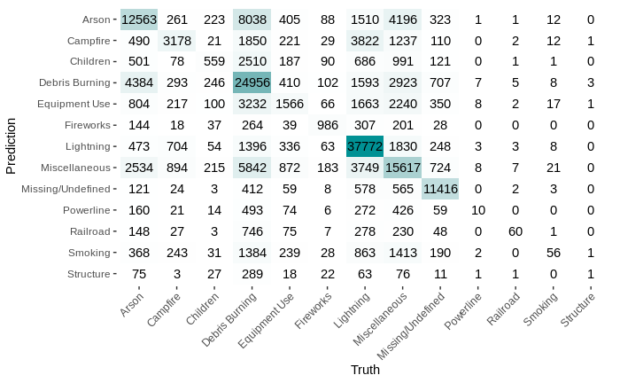

```r
cm <- test2 %>% conf_mat(preds, STAT_CAUSE_DESCR)
autoplot(cm, type="heatmap")+scale_fill_gradient(low="white", high="#009194") +theme(axis.text.x = element_text(angle = 45, hjust = 1))
```

```r
#dbDisconnect(conn = con)
```

```r
# misc
# units not found in units table
# dbGetQuery(con, "with ids as (SELECT unitId from NWCG_UnitIDActive_20170109) select count(distinct NWCG_REPORTING_UNIT_ID) from fires where NWCG_REPORTING_UNIT_ID not in ids")
#   count(distinct NWCG_REPORTING_UNIT_ID)
# 1                                     17
# 34757 fire records belong to these units
```

```r
# ??
#dbGetQuery(con, "SELECT COUNT(*), WildlandRole FROM NWCG_UnitIDActive_20170109 GROUP BY 2")
#   COUNT(*)                 WildlandRole
# 1      328 Dispatch/Coordination Center
# 2       29            Fire/Radio Cashes
# 3        8     Incident Host Functional
# 4     5228     Incident Host Geographic
# 5      266       Resource Provider Only
# 6        8            Training Facility

# > dbGetQuery(con, "SELECT COUNT(*) FROM NWCG_UnitIDActive_20170109 WHERE Parent IS NULL")
#   COUNT(*)
# 1     5867
# > dbGetQuery(con, "SELECT COUNT(*) FROM NWCG_UnitIDActive_20170109 WHERE Parent IS NOT NULL")
#   COUNT(*)
# 1        0
```